This is test task for MMD Smart done by Karina Chumak.  
Task: create spam/not-spam classificator using DL and clustering, provide exploratory data analysis.

```python
import pandas as pd
import matplotlib.pyplot as plt
import seaborn as sns
import time
import numpy as np
import warnings
warnings.filterwarnings('ignore')
figsize = (15,5)
```

```python
data = pd.read_csv('data/MMD_DS_test (2).csv')
```

# 1. Exploratory data analysis

```python
data.head(20)
```

|  | CDR_TEXT | labels |
| --- | --- | --- |
| 0 | FELIZ ANIVERSARIO TAIANE!Agende o seu retorno ... | spam |
| 1 | Your iROKOtv verification code is 2920 | spam |
| 2 | Enjoy two epic offers at asc-ply.com/AS: A 100... | spam |
| 3 | olsun dileklerimizle. ANADOLU SİGORTA https:/... | spam |
| 4 | 85254 is Your Yahoo Account Key | spam |
| 5 | Danny We have you Approved. Please call us imm... | spam |
| 6 | Cash payout of MK 2330000 from account: 263851... | spam |
| 7 | .لما تروح ركب دولاب شهد واغسل باقى البسطاتات م... | spam |
| 8 | <#> 55008 هو رمز فيسبوك الخاص بك Laz+nxCarLW | spam |
| 9 | Unsubscribe: https://ig.me/w/1Ks06aa5zchffKn | spam |
| 10 | <#> 39398 هو رمز فيسبوك الخاص بك Laz+nxCarLW | spam |
| 11 | لثنين اديت الورق لي زول يخلص لي فيهو يوم الارب... | spam |
| 12 | Hey Berry, just a friendly reminder that you h... | spam |
| 13 | Don't miss out on 30% Offer! Pay MWK.2310 to A... | spam |
| 14 | 384600 e o codigo de redefinicao de senha do F... | spam |
| 15 | Use 634 721 para verificar a conta do Instagra... | spam |
| 16 | Enjoy two epic offers at rfc-ply.com/rfd: A 10... | spam |
| 17 | Your iROKOtv verification code is 4916 | spam |
| 18 | Truecaller code 874696 | spam |
| 19 | imo code: 2284 | spam |

First - we'll check for missing values in the data in general

```python
data.isna().sum()
```

```
CDR_TEXT    1
labels      0
dtype: int64
```

```python
data[data['CDR_TEXT'].isna()]
```

|  | CDR_TEXT | labels |
| --- | --- | --- |
| 836002 | NaN | normal |

As long as we have a single missing value and it is in the text itself , we'll drop it.

```python
data.dropna(inplace=True)
```

```python
data['labels'].value_counts()
```

```
normal    894537
spam       89939
Name: labels, dtype: int64
```

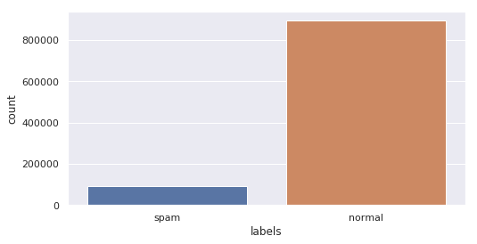

```python
sns.set(rc={'figure.figsize':(8,4)})
sns.countplot(x = 'labels', data=data)
```

As we can see, the dataset is imbalanced : there are 10 times as many normal letters as there are spam letters. Let's have a look at normal letters. The first thing that cathces the eye is that all of them address by name

```python
data.loc[data['labels'] == 'normal','CDR_TEXT'].head()
```

```
89939    Hi Leeann, We are looking for people to start ...
89940    Well-done Molly for taking 3RD place in our Te...
89941    Hi Innocent, We are looking for people to star...
89942    Hi Farook, We are looking for people to start ...
89943    Hi Charlie, We are looking for people to start...
Name: CDR_TEXT, dtype: object
```

Let's check, how many characters each type of letter has and look at the distribution.

```python
data['char_cnt'] = data['CDR_TEXT'].apply(lambda x : len(x))
```

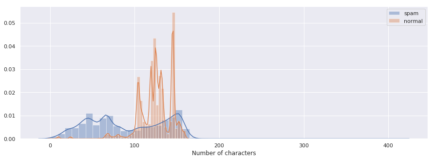

```python
sns.set(rc={'figure.figsize':figsize})
sns.distplot(data.loc[data['labels'] == 'spam','char_cnt'],label = 'spam')
sns.distplot(data.loc[data['labels'] == 'normal','char_cnt'], label = 'normal')
plt.legend()
plt.xlabel("Number of characters")
```

A lot of normal letters contain more tham 100 characters. Let's check, what percent of letters that have more than 100 characters, are normal.

```python
threshold = 100
len(data[(data['char_cnt'] >= threshold) & (data['labels'] == 'normal')])/len(data[data['char_cnt'] >= threshold])
```

```
0.9547315715895669
```

95% normal letters among letters with more than 100 chars. This may be helpful for baseline model. Let's check, what precision and recall we can get from as simple model as classifying by number of chars. We'll use precision and recall because classes are imbalanced.  
We'll set **0 to normal, 1 to spam**

```python
# 0-normal
# 1-spam
```

```python
data['predicted'] = (data['char_cnt'] < threshold)*1
data['is_spam'] = (data['labels'] == 'spam')*1
```

```python
from sklearn.metrics import accuracy_score, f1_score, precision_score, recall_score,confusion_matrix
prec = precision_score(data['is_spam'], data['predicted'], average="macro")
rec = recall_score(data['is_spam'], data['predicted'], average="macro")
acc = accuracy_score(data['is_spam'], data['predicted'])
```

```python
print('Baseline model, classifying by number of chars')
print('Precision:{}'.format(prec))
print('Recall:{}'.format(rec))
print('Accuracy:{}'.format(acc))
```

```
Baseline model, classifying by number of chars
Precision:0.7293574148867219
Recall:0.7497141538838832
Accuracy:0.9094431961774588
```

Let's compare these results with simple marking all letters as normal.

```python
data['guessed'] = 0
prec = precision_score(data['is_spam'], data['guessed'], average="macro")
rec = recall_score(data['is_spam'], data['guessed'], average="macro")
acc = accuracy_score(data['is_spam'], data['guessed'])
print('Marking all examples as normal')
print('Precision:{}'.format(prec))
print('Recall:{}'.format(rec))
print('Accuracy:{}'.format(acc))
```

```
Marking all examples as normal
Precision:0.45432138518359005
Recall:0.5
Accuracy:0.9086427703671801
```

As we can see, in this case accuracy is 90% due to imbalanced classes, however precision and recall are much worse. We'll keep all these results in mind for future model development.  
Now we'll check languages, in which letters are written, using library *langdetect*. It fails with errors when text contains only nubers or ur,for example. So, this has to be catched manually.

```python
from langdetect import detect
```

```python
def get_lang(x):
    try:
        lang = detect(x)
    except:
        lang = 'none'
    return lang
```

This works really slow on entire dataset, so we'll take a sample of 20000 letters and explore it

```python
sample = data.sample(n = 20000)
sample['lang'] = sample['CDR_TEXT'].apply(get_lang)
```

Next we'll select 20 most common languages and take a look at percentage of spam in them.

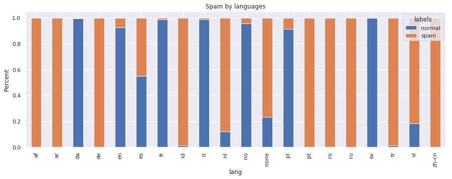

```python
popular_langs = sample['lang'].value_counts().head(20).index
subsample = sample[sample['lang'].isin(popular_langs)]
df_lang_grouped = subsample.groupby(['lang','labels']).size()/subsample.groupby(['lang']).size()
df_lang_grouped.unstack().plot(kind='bar',stacked=True,figsize=figsize,title='Spam by languages')
plt.ylabel("Percent")
```

```python
from wordcloud import WordCloud,STOPWORDS
```

```python
spam = data[data['labels'] == 'spam']
normal = data[data['labels'] == 'normal']
```

```
(-0.5, 399.5, 199.5, -0.5)
```

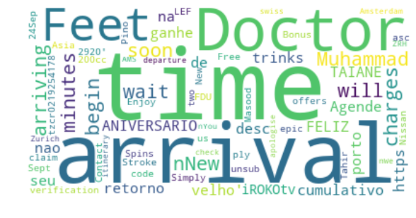

```python
spam_text = spam.CDR_TEXT.values
spam_wordcloud = WordCloud(background_color='white',stopwords = STOPWORDS).generate(str(spam_text))

plt.imshow(spam_wordcloud, interpolation='bilinear')
plt.axis("off")
```

```
(-0.5, 399.5, 199.5, -0.5)
```

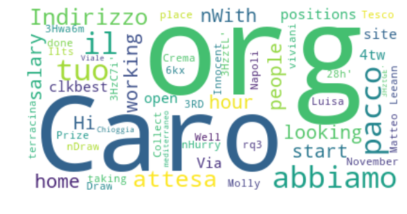

```python
normal_text = normal.CDR_TEXT.values
normal_wordcloud = WordCloud(background_color='white',stopwords = STOPWORDS).generate(str(normal_text))

plt.imshow(normal_wordcloud, interpolation='bilinear')
plt.axis("off")
```

"Caro" means "Dear" in italian, which proves that normal letters often have address by name

Checking, whether spam or normal letters contain url, using regular expressions

```python
import re
regex ='http[s]?://(?:[a-zA-Z]|[0-9]|[$-_@.&+]|[!*\(\),]|(?:%[0-9a-fA-F][0-9a-fA-F]))+'
has_url = lambda x : bool(re.search(regex, x))
```

```python
data['has_url'] = data["CDR_TEXT"].apply(has_url)
```

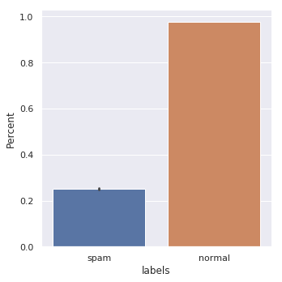

```python
sns.set(rc={'figure.figsize':(8,4)})
sns.factorplot(x = 'labels', y='has_url', data=data,kind = 'bar')
plt.ylabel("Percent")
```

Almost each normal letter contains a URL, while less than 30% of spam letters do. I would expect completely opposite results, so may be it's just a coincidence

```python
from tld import get_tld
get_suffix = lambda x : get_tld(re.search(regex, x).group(0), fix_protocol=True,fail_silently=True)
```

```python
data_with_url = data[data['has_url']]
data_with_url['suffix'] = data_with_url['CDR_TEXT'].apply(get_suffix)
```

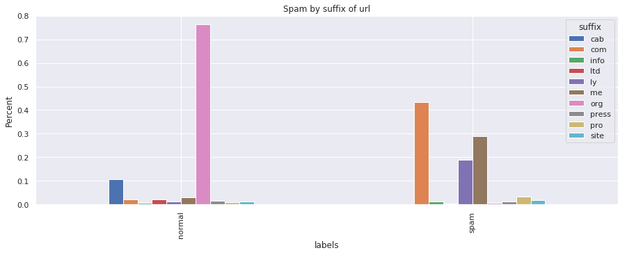

```python
popular_suff = data_with_url.suffix.value_counts().head(10).index
t = data_with_url[data_with_url['suffix'].isin(popular_suff)]
df_suffix_grouped = t.groupby(['labels','suffix']).size()/t.groupby(['labels']).size()
df_suffix_grouped.unstack().plot(kind='bar',figsize=(figsize),title='Spam by suffix of url')
plt.ylabel("Percent")
```

Normall letters usually have links with TLD *.org*, which makes sense, because it's for non-profit organizations. There are almost no letters in spam with such top-level-domain. In spam most common links have *.com,.me,.ly* domains.

**P.S.** For some reason, a lot of letters,containing code for verificationg or password reset, for example `Код подтверждения аккаунта : 021 659` or `Snapchat code: 163853. Do not share it`, etc. are marked as spam, while they are actually important letters somtimes. This may mean that the dataset is not entirely correct and needs some manual processing.

```python
spam['CDR_TEXT'].tail()
```

```
89934    585580（设备锁验证码），用于QQ34*******9开启设备锁，请勿转发。如不想接收此...
89935    951171 — код для сброса вашего пароля в «Faceb...
89936    Muhammad is arriving soon in a New Asia 200cc ...
89937    Muhammad Tahir Masood is arriving soon in a Ni...
89938    24Sep \nNew departure time Zurich (ZRH): 19:25...
Name: CDR_TEXT, dtype: object
```

## Data cleaning and preprocessing

```python
import nltk
porter = nltk.PorterStemmer()
```

```python
nltk.download('stopwords')
```

```
True
```

We'll delete all stopwords from text,using nltk stopwords for most common languages, obtained earlier.

```python
top_langs = ['english','french','italian','swedish','danish','norwegian','turkish','portuguese','german','arabic','spanish','indonesian','russian','dutch']
stop_words = []
for lang in top_langs:
    stop_words += nltk.corpus.stopwords.words(lang)
```

Text preprocessing includes next steps:

- deleting all unicode characters
- substituting all email addresses with **emailaddr**
- substituting all url with **httpaddr**, saving most common top-level-domains('org','com','me','ly','cab')
- substituting all money symbols with **moneysymb**
- substituting all phone numbers with **phonenumbr**
- substituting all numbers with **numbr**
- remove all punctuation and extra whitespaces

```python
def preprocess_text(messy_string):
    cleaned = re.compile(r'[\u064B-\u0652\u06D4\u0670\u0674\u06D5-\u06ED]+',re.UNICODE).sub('', messy_string)
    cleaned = re.sub(r'\b[\w\-.]+?@\w+?\.\w{2,4}\b', 'emailaddr', cleaned )
    if has_url(cleaned):
        suffix = get_suffix(cleaned)
        if suffix in ['org','com','me','ly','cab']:
            cleaned += ' {}'.format(suffix)
    cleaned = re.sub(r'http[s]?://(?:[a-zA-Z]|[0-9]|[$-_@.&+]|[!*\(\),]|(?:%[0-9a-fA-F][0-9a-fA-F]))+', 'httpaddr',
                     cleaned)
    cleaned = re.sub(r'£|\$', 'moneysymb', cleaned)
    cleaned = re.sub(
        r'\b(\+\d{1,2}\s)?\d?[\-(.]?\d{3}\)?[\s.-]?\d{3}[\s.-]?\d{4}\b',
        'phonenumbr', cleaned)
    cleaned = re.sub(r'\d+(\.\d+)?', 'numbr ', cleaned)
    cleaned = re.sub(r'[^\w\d\s]', ' ', cleaned)
    cleaned = re.sub(r'\s+', ' ', cleaned)
    cleaned = re.sub(r'^\s+|\s+?$', '', cleaned.lower())
    return ' '.join(
        porter.stem(term)
        for term in cleaned.split()
        if term not in set(stop_words)
    )
```

```python
# this cell was run locally
s = time.time()
X = data['CDR_TEXT'].apply(preprocess_text)
print(time.time()-s)
```

```
2568.5510444641113
```

```python
# this cell was run on Google Colab, it took more time - why?
s = time.time()
X =data['CDR_TEXT'].apply(preprocess_text)
print(time.time()-s)
```

```
3351.3830766677856
```

```python
X['labels'] = data['is_spam']
```

After preprocessing a lot of CDR_text values became NaN, because they contained only stopwords, punctuation, unicode symbols etc. We'll fill such values with **notext**

```python
X.loc[X['CDR_TEXT'].isna(),'CDR_TEXT'] = 'notext'
```

```python
X.isna().sum()
```

```
CDR_TEXT    0
labels      0
dtype: int64
```

```python
X.to_csv('data/processed_CDR_TEXT_labels.csv',index = False)
```